# Vos requêtes SQL 10 000x plus rapide, durablement

*Alain Lesage*

Devfest Nantes 2025

## *Question ?*

### Que fait un DBA :

- **administration**
  - installation d’instances
  - construction de replicas
  - maintenance
  - sauvegardes
  - droits utilisateurs
- **optimisation**
  - analyse des plans d’exécution
  - création d’index

### Que fait *VRAIMENT* un DBA ?

- **conçoit**
  - modèle de données
  - architecture (réplication, **HA**)
- **conseille**
  - utilisation (OLTP, OLAP, monolithe, µ-services)
  - niveau de service (**RTO**, **RPO**, **SLO**…)
  - ingénierie (choix des outils, intégration)
- **décide**
  - pour 5 à 10 ans au moins

## PostgreSQL 🐘

- postgresql.org
- Né en tant que projet universitaire
- **Libre**, gratuit et communautaire
- Modulaire et **extensible**
- Logiciel **VRAIMENT** open-source ([licence PostgreSQL](https://opensource.org/license/postgresql))
  - [*The SSPL is Not an Open Source License* (opensource.org)](https://opensource.org/license/postgresql)
- **DALIBO** reconnu **major sponsor** par le projet

### **LA référence !**

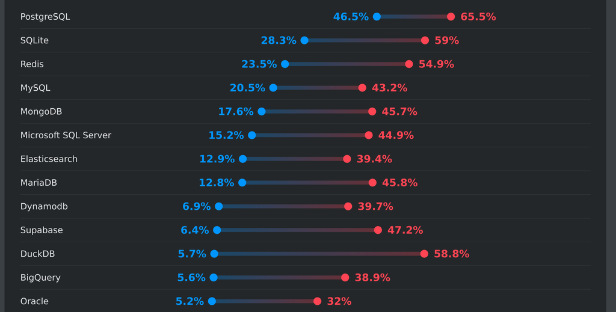

[2025 Stack Overflow Developer Survey](https://survey.stackoverflow.co/2025/technology#2-databases)

## ℹ️ Message de service

- *PAS de paramètre **magique***
- *PAS de **“quick win”***

## Menu

- Bases de données relationnelles
- Le gruyère de la performance
  - Matériel
  - Indexation
  - Statistiques
- Big Data, NoSQL & AI
- La vraie vie
- À retenir

## Bases de Données Relationnelles

### Bases de Données

- **Atomicité**
  - transactions (`BEGIN`, `COMMIT`, `ROLLBACK`)
- **Cohérence**
  - contraintes (`UNIQUE`, `NOT NULL`, `CHECK`…)
- **Isolation**
  - Multiversion Concurrency Control (MVCC)
- **Durabilité**
  - journalisation et double écriture

## Modèle Relationnel

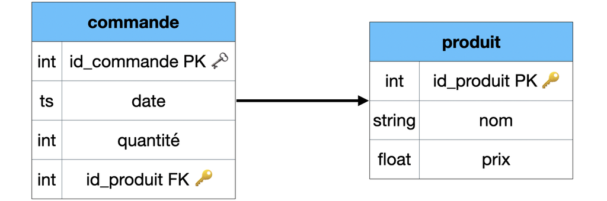

- Depuis 1970
- Clés primaires & clés étrangères
- **Indexation**
- Langage **SQL**

### MVCC Exemple

```sql
INSERT INTO ma_table VALUES
  ('Bob',     1000),
  ('Alice',   2000),
  ('Charlie',  800);
```

| *xmin* | *xmax* | nom | montant |
| --- | --- | --- | --- |
| 1 |  | Bob | 1000 |
| 1 |  | Alice | 2000 |
| 1 |  | Charlie | 800 |

### MVCC Exemple

```sql
UPDATE ma_table SET montant = 1500 WHERE nom = 'Bob';
```

| *xmin* | *xmax* | nom | montant |
| --- | --- | --- | --- |
| 1 | 2 | Bob | 1000 |
| 1 |  | Alice | 2000 |
| 1 |  | Charlie | 800 |
| 2 |  | Bob | 1500 |

### MVCC Exemple

```sql
DELETE FROM ma_table WHERE nom = 'Charlie';
```

| *xmin* | *xmax* | nom | montant |
| --- | --- | --- | --- |
| 1 | 2 | Bob | 1000 |
| 1 |  | Alice | 2000 |
| 1 | 3 | Charlie | 800 |
| 2 |  | Bob | 1500 |

```sql
BEGIN;
UPDATE ma_table SET montant = montant - 250 WHERE nom = 'Alice';
UPDATE ma_table SET montant = montant + 250 WHERE nom = 'Bob';
COMMIT;
```

| *xmin* | *xmax* | nom | montant |
| --- | --- | --- | --- |
| 1 | 2 | Bob | 1000 |
| 1 | 4 | Alice | 2000 |
| 1 | 3 | Charlie | 800 |
| 2 | 4 | Bob | 1500 |
| **4** |  | **Alice** | **1750** |
| **4** |  | **Bob** | **1750** |

### Maintenance

- processus `autovacuum`
  - marque les lignes mortes
  - permet leur recyclage
  - pratique…
  - …mais pas magique !
- Commande `VACUUM`